DR Screening

# Retinal Review Workbench

AI-assisted retinal review and dataset workflow

Clinician-controlled · on-premise oriented · research POC

The clinical problem

## Screening volume grows faster than specialist attention.

The Workbench is designed to make review more structured, traceable, and focused on the cases that need human attention.

### Many images

Routine fundus photographs arrive with different quality, context, and clinical urgency.

### Limited time

Ophthalmologist attention is the scarce resource. The interface should reduce avoidable navigation and re-entry work.

### Human judgment

The product supports a clinician's decision; it does not make an autonomous referral or treatment decision.

Conceptual framing · not a local outcome claim

Clinical problem framing adapted from owner-provided ophthalmologist deck; claims are intentionally non-quantitative.

Positioning

## The system is an assistive review layer above the image.

### It is

- review support
- AI evidence with visible provenance
- human final decision
- dataset and audit workflow

### It is not

- autonomous diagnosis
- automatic treatment decision
- automatic patient notification
- a replacement for ophthalmologist judgment

Version 1 scope

## The first release is deliberately narrow.

### Input

Color fundus photography and supported single-frame ophthalmic DICOM.

→

### Evidence

RETFound DR grade suggestion and PRISM-DR lesion ROI suggestions.

→

### Review

Clinician final DR grade, annotation correction, and confirmation.

→

### Output

Provenance-preserving dataset export and audit record.

Today: retinal photographyFuture / proposed: broader modalitiesNot claimed: PACS integration

The people behind the workflow

## The system boundary is also a team boundary.

**Watcharin Buason**Managing Director

**Benjamaporn Jeankor**Business Solution Lead

**Dependa**Project Manager

**Thiphornphan Uthaithat**Head of Administration

**Siripon Srihangpiboon**AI / Computer Vision Lead

**Patthadon Changate**AI / Data Engineer Lead

**Sansern Makcharoen**Full-stack & DevOps Lead

Organization chart source: DR_Screening_OrgChart.pptx · roles preserved exactly

Meet the team

## Product, clinical context, models, and operations meet in one loop.

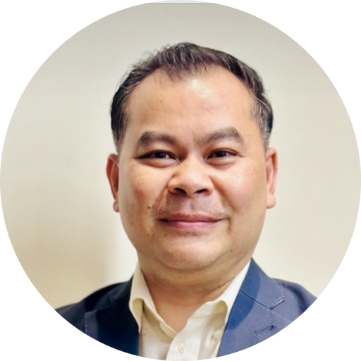

### Watcharin Buason

Managing Director

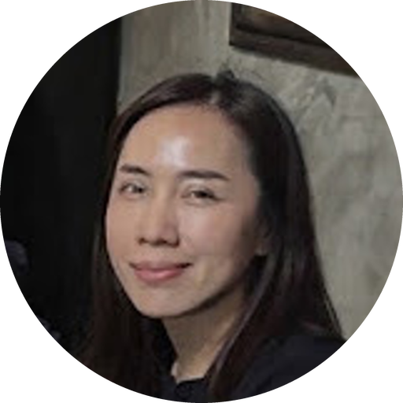

### Benjamaporn Jeankor

Business Solution Lead

PM

### Dependa

Project Manager

HA

### Thiphornphan Uthaithat

Head of Administration

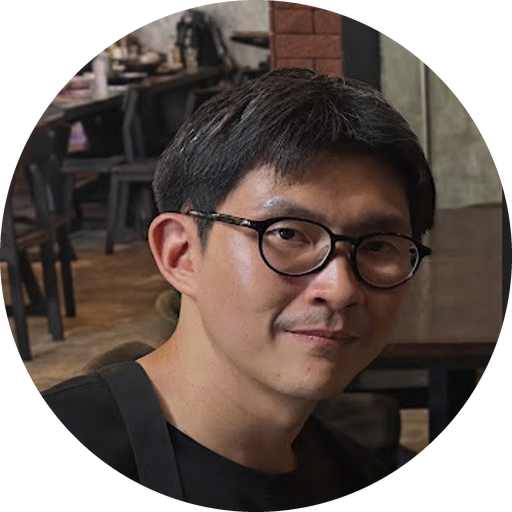

### Siripon Srihangpiboon

AI / Computer Vision Lead

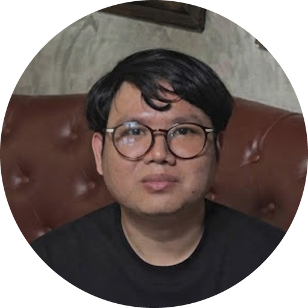

### Patthadon Changate

AI / Data Engineer Lead

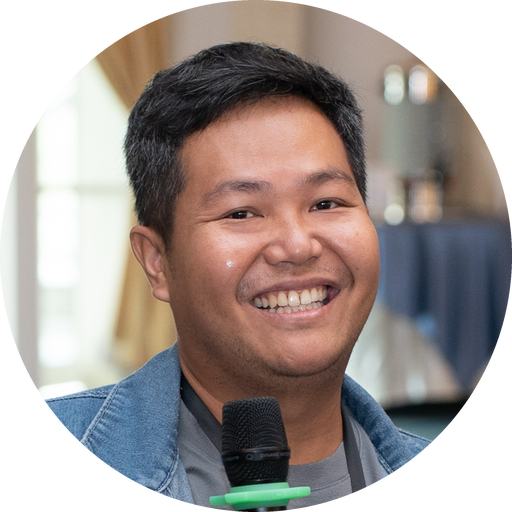

### Sansern Makcharoen

Full-stack & DevOps Lead

Five portraits from the owner-provided organization deck; initials mark roles without supplied portraits.

Two tasks, two evidence types

## AI evidence stays below the human review decision.

### RETFound → DR grade suggestion

Global classification evidence for a five-class DR suggestion. The model score is not a calibrated clinical probability.

### PRISM-DR → lesion ROI suggestions

Object-level evidence for Microaneurysm, Hemorrhage, Hard exudate, and Soft exudate.

### Clinician review remains authoritative.

Evidence can inform inspection, correction, or escalation. It cannot confirm a case by itself.

Open clinical validation questions →

Model 01 · RETFound

## RETFound contributes retinal representation research; this product adds a local task head.

### Research context

RETFound is a retinal foundation-model project built around self-supervised representation learning across retinal imaging research tasks.

Upstream repository and Nature paper

### Product boundary

The current product identity is retfound-aptos5, a five-class DR suggestion path. Upstream benchmark results are not local product validation.

Model evidenceHuman grade is authoritative

Sources: github.com/rmaphoh/RETFound · Nature s41586-023-06555-x · local provider identity in repository

Model 02 · PRISM-DR

## PRISM-DR proposes where a lesion may be; it does not make the diagnosis.

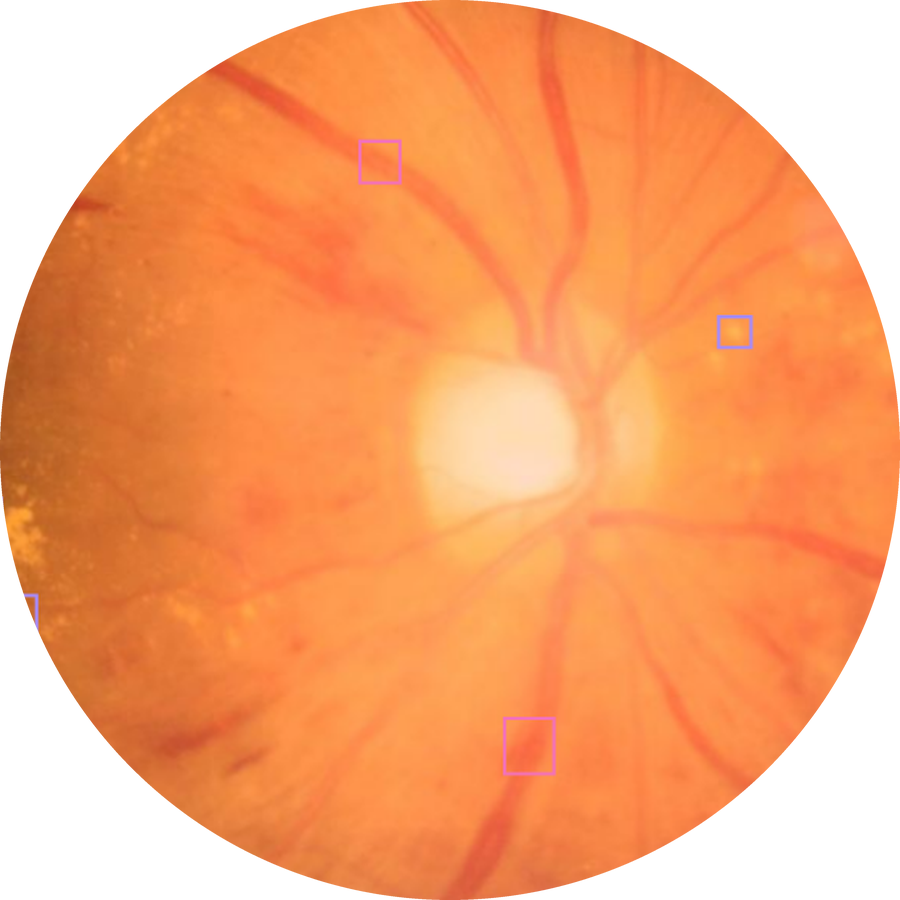

Upstream example / attribution required

MicroaneurysmHemorrhageHard exudateSoft exudate

The Workbench presents lesion ROI suggestions as inspectable evidence. A clinician can use, correct, or remove a suggestion while preserving the original AI provenance.

Source: github.com/zubeyrozeren/PRISM-DR and upstream paper · upstream reported output is not product validation

Uncertainty is part of the workflow

## Unclear image ≠ normal image. No detection ≠ no lesion.

### Image quality

When assessment is inadequate, the correct action is to recognize that limitation and follow the local clinical pathway. The product does not silently convert uncertainty into normality.

### Model output

An empty PRISM-DR result is an empty suggestion set, not proof that a lesion is absent. Human review remains the authority.

The UI should make uncertainty legible without pretending to calibrate it.

Terminology informed by ICO Guidelines for Diabetic Eye Care (2017) and human-AI transparency guidance

Image selection boundary

## The Workbench receives a selected, approved image; it does not browse hospital storage.

**1 · Hospital-controlled**Candidate images remain under hospital control.

→

**2 · Authorized user**Clinician or authorized hospital user selects the candidate.

→

**3 · Approved staging**The original file is staged into the Workspace input folder.

→

**4 · Workbench**Review, provenance, annotations, and export begin here.

The project team monitors coverage outside the Workbench. Clinicians do not manage sampling quotas during routine selection.

Canonical boundary: ADR-0006 and Team Image Sampling Requirements

The current clinician path

## One case moves forward through a small number of explicit decisions.

**Confirm Image**Confirm pseudonymous context and eye.

→

**Review**Inspect the image and optional AI evidence.

→

**Clinician Review**Select and confirm the final DR grade.

→

**Annotations only when needed**Confirm, correct, remove, or add human evidence.

→

**Next case**Advance without losing confirmation state.

AI optionalHuman confirmation explicitAnnotation only when needed

Current workflow after Phase 1 clinician-flow redesign

Product walkthrough 01

## Worklist makes the next safe action visible.

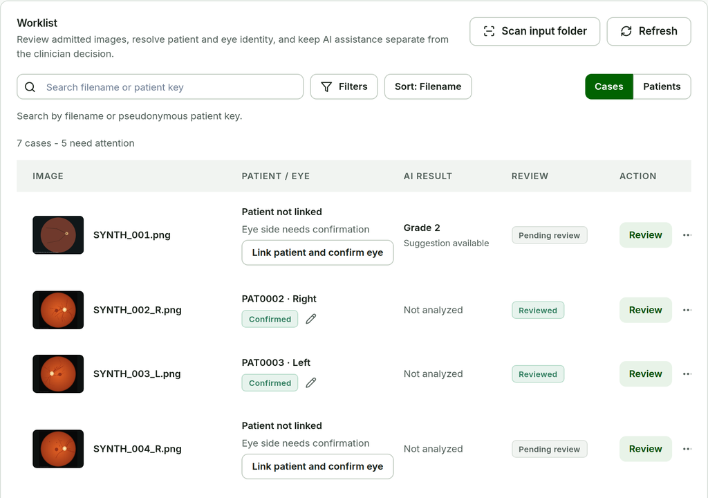

### Select a case

Choose the staged case from the Worklist, then open Confirm Image.

### Confirm context

Review pseudonymous patient key and laterality. Filename hints are evidence only.

UI screenshot using public/synthetic fixture

Current UI screenshot · no PHI · clinician manual source

Product walkthrough 02

## Review puts the retinal image first and evidence beside it.

### RETFound

Optional DR grade suggestion. The score is model evidence, not calibrated probability.

### PRISM-DR

Optional lesion ROI suggestions. Empty output does not prove absence.

Product walkthrough 03

## The primary action is one explicit human decision.

### Confirm final DR grade

Record the clinician's authoritative grade and continue to annotation review.

THEN

### Review annotations when needed

Confirm the active annotation set only when annotation work is required.

### The grade requirement is deliberate.

The workflow does not confirm a case until a clinician has explicitly selected a final DR grade.

Current Clinician Review behavior after Phase 1

Product walkthrough 04

## Annotation is a focused correction loop, not a second queue.

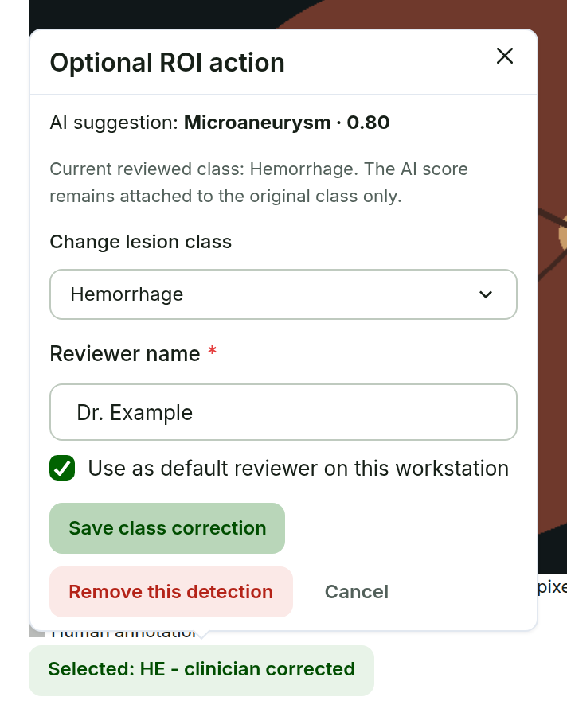

1

**Click the AI ROI**

Open the action popover for the selected suggestion.

2

**Confirm, correct, or remove**

Make the smallest human change needed for the active annotation set.

3

**Preserve original evidence**

AI class, score, geometry, and source detection remain auditable.

UI screenshot using public/synthetic fixture

Current annotation editor behavior after Phase 1 · human review remains authoritative

Input derivatives and output

## The source stays immutable while review uses an explicit analysis derivative.

### Original ophthalmic DICOM

Preserved source identity and provenance.

→

### Decoded/rendered derivative

Used for zoom, pan, model envelope, and annotation coordinates.

→

### Human review

Grade or corrected annotation.

→

### Grouped export

PNG/JPEG derivatives, manifests, hashes, and DICOM provenance.

Unsupported modality, multi-frame, codec, and decode failures retain their specific status. They are not silently treated as normal retinal input.

Current admission, derivative, annotation, and export contracts

On-premise oriented deployment

## The workstation and GPU Model API have different trust and runtime roles.

**Windows review workstation**

Browser UI, local review state, `APP_PROFILE=review`, `MODEL_RUNTIME=remote`, no model weights.

**Protected hospital LAN**

Only the approved network boundary connects the workstation to the service.

**Linux GPU Model API**

`APP_PROFILE=model_api`, verified local assets, CUDA device, one worker, controlled service.

The workstation can keep operating locally when remote model assistance is unavailable; model evidence is optional.

Architecture sources: docs/adr/architecture/ · operations/model-server guide

What we need from ophthalmologists

## Help us make the human-AI team clinically useful.

We are looking for feedback on workflow fit, evidence presentation, ungradable-image handling, uncertainty wording, and what should count as useful validation.

Review the real imageChallenge the uncertaintyKeep the clinician in control

Branch · clinical validation

## Which evidence actually changes the next clinical action?

### Global evidence

When does a DR grade suggestion help a specialist review faster, and when does it add noise?

### Lesion evidence

Which ROI types and visual cues are useful for inspection, correction, or escalation?

Return to the main deck with the presenter Back action.

Branch · clinical validation

## Where should the workflow draw the line?

### Ungradable

What wording and local pathway make inadequate assessment explicit without implying normality?

### Human-AI team

Which study design best evaluates the combined team rather than a model score in isolation?

Return to the main deck with the presenter Back action.